# Week 11: Data Analysis and Interpretation Part II

Dr. T. Kody Frey

Associate Professor | School of Information Science

# Housekeeping

## Project Timeline

Only 6 weeks left! ALL IRBs have been submitted

Goal is to launch survey as soon as possible (continue to build Qualtrics surveys)

We will work with as many people as we can get!

After Paper #3, front end of study (lit review, RQs/Hs, should be complete)

## What’s Next?

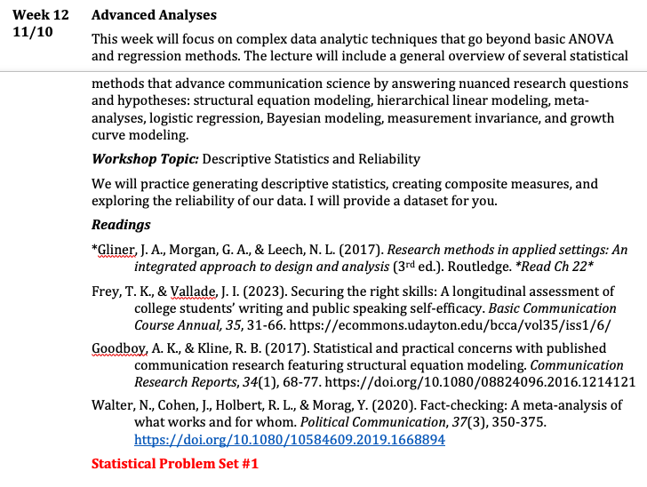

## Overview of Today

Variable Relationships!

- Brief Review
- Correlation
- Partial Correlation
- Multiple Regression

## Brief Review on BG and WS Difference Tests

Already Covered:

- Descriptive Statistics
- Inferential Statistics
- Nonparametric tests (Chi-Square)
- Group Differences (t-tests)
- ANOVA, Factorial ANOVA,
- ANCOVA, MANOVA, Repeated Measures MANOVA (Sort of)

## Visualizing

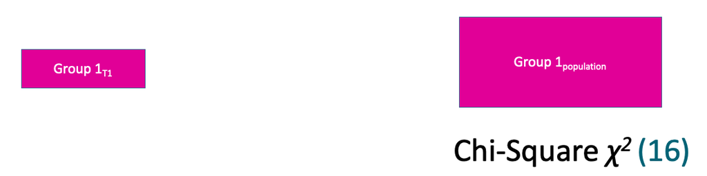

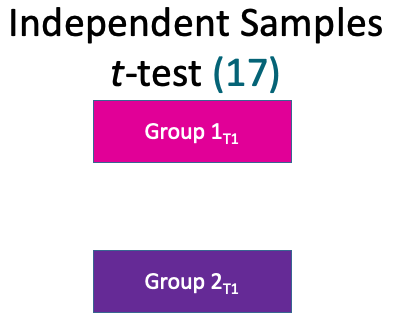

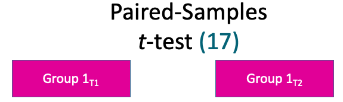

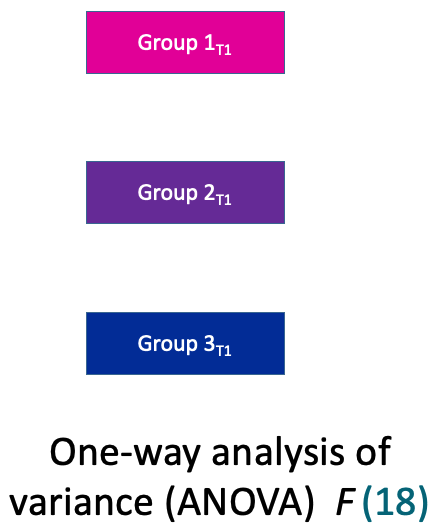

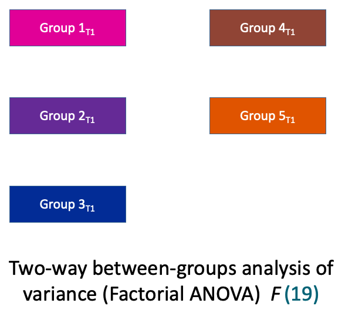

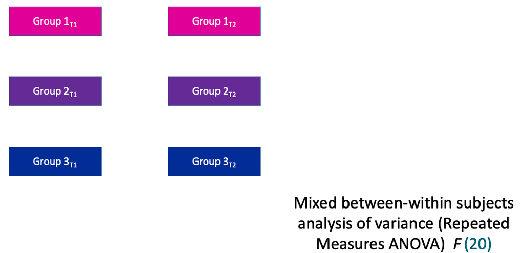

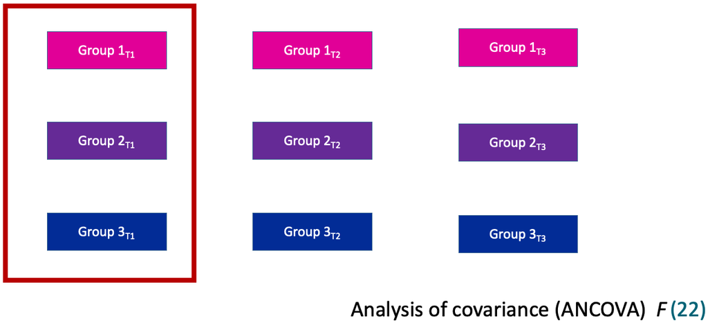

## Quick Knowledge Check

What is the difference between a One-way ANOVA and a Factorial ANOVA?

## Real Life

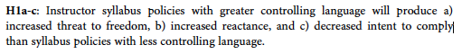

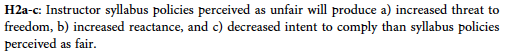

## Real Life

- Comparing Means
- Threat to Freedom
- Reactance
- Compliance

2 x 2 Factorial Design

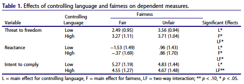

The analysis revealed significant main effects of controlling language, F(1, 301) = 16.16, p < .001, η2 = .05, and fairness, F(1,301) = 41.66, p < .001, η2 = .12, as well as **a significant interaction**, F(1, 301) = 7.41, p < .01,η2 = .02.

The analysis revealed significant main effects of controlling language, F(1, 301) = 8.60, p < .01, η2 = .03, and fairness, F(1, 301) = 104.26,p < .001, η2 = .26, as well as **a significant interaction**, F(1, 301) = 11.91, p < .001, η2 = .04.

The analysis revealed a significant main effect of controlling language, F(1, 301) = 8.03, p < .01, η2 = .03, and a marginally significant interaction, F(1, 301) = 3.22, p = .07, η2 = .01; the fairness main effect was not significant, F(1, 301) = 1.01, p = .32, η2 = .00.

## What Test is Appropriate!

- 1 between groups IV (2 levels), 1 normally-distributed DV
  - EX: Do men and women differ in stats achievement?
- 2 categorical variables
  - EX: Is gender associated with political party preference?
- A 2 x 3 between subjects design, 1 normally-distributed DV
  - EX: Do gender and class time (morning, noon, night) interact to affect achievement?
- 1 between groups IV (4 levels), 1 normally-distributed DV
  - EX: Do NCAA basketball tournament regions differ in terms of field goal percentage?

## What Test is Appropriate!

- 1 within subjects IV (2 levels), 1 normally-distributed DV
  - EX: Do students have more research methods knowledge at the end of 665 compared to the beginning?
- 1 within subjects IV (4 levels), 1 normally-distributed DV
  - EX: How does research method knowledge change from January to April (4 months)?
- A 2 x 3 x 2 mixed design with repeated measures on the third variable, 1 normally-distributed DV
  - EX: Do gender and class time (morning, noon, night) lead students to have better grades between Fall and Spring semester?
- 1 between groups IV (4 levels), 3 normally-distributed DVs
  - EX: Does teacher type (lecturer, non-tenured professor, graduate student, tenured professor) differ in terms of their credibility (competence, caring, goodwill)?

## Example Study 1

- Overview
- Test?

[figure not shown]

[figure not shown]

## Example Study 2

[figure not shown]

[figure not shown]

[figure not shown]

[figure not shown]

## Example Study 3

- Overview
- Test?

[figure not shown]

[figure not shown]

## What If!?

- Overview
- Option 1
- Option 2
- Option 3

[figure not shown]

[figure not shown]

[figure not shown]

[figure not shown]

# GLM Ch. 21 & (Parts of) 22

21: *Analysis and Interpretation of Basic Associational Research Questions*

22: *Analysis and Interpretation of Complex Associational Questions*

## Ch. 21 Overview

Chapter 21 (p. 369-385) covers:

- Analyzing Continuous Variables with Parametric Statistics
  - Pearson Product-Moment Correlation (r)
  - Statistical Significance
  - Correlation Matrix
  - Effect Sizes
  - Confidence Intervals
- Using Nonparametric Associational Statistics
  - Spearman Rank-Order Correlation Coefficient (rho)
  - Kendall Tau Coefficient (tau)
  - Misleading Correlation Coefficients (p. 374-376)
  - Associational Statistics for Nominal Variables
  - The Chi-Square Test and Effect Size Indices

## Remember Pearson

## What are correlations?

An index of the strength of the linear relationship between two variables

- Ranges from -1 to +1
- A positive relationship means that as scores on one variable increase, scores on the other variable also increase.
- An inverse relationship means that a high score on one variable is associated with a low score for the same person on the other variable and vice versa.

## Correlation Matrix

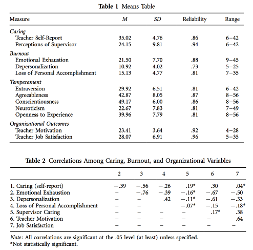

Teven, J.J. (2007). Teacher temperament: Correlates with teacher caring, burnout, and organizational outcomes. *Communication Education, 56*, 382-400.

## Correlation Matrix

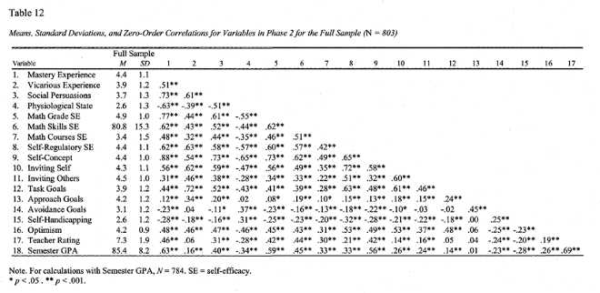

Usher, E. L. (2007). Tracing the origins of confidence: A mixed methods exploration of the sources of self-efficacy beliefs in mathematics (Unpublished doctoral dissertation). Emory University, Atlanta, GA.

## Correlation Matrix

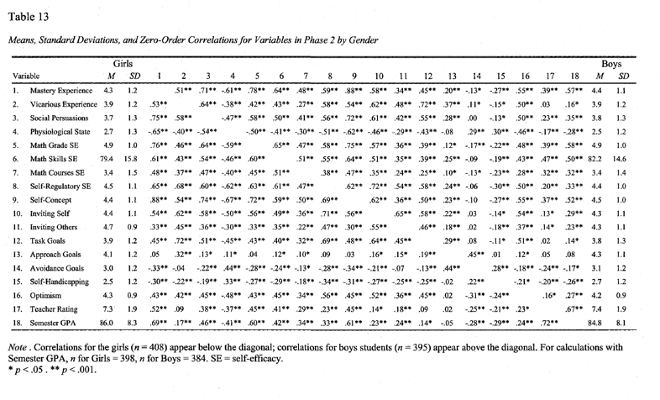

## Ch. 22 Overview

- Use and Interpretation of Multiple Regression
  - Correlation and Bivariate Regression
  - Conditions and Assumptions
  - Computing Multiple Regression (partial correlations)
  - **Hierarchical Multiple Regression**
  - **Simultaneous Multiple Regression**
  - **Stepwise Multiple Regression**
  - Logistic Regression
  - Discriminant Analysis

## What is Regression?

In linear regression, the regression coefficient represents the amount of change in the dependent variable for one-unit change in the independent variable.

## Defining Types of Regression

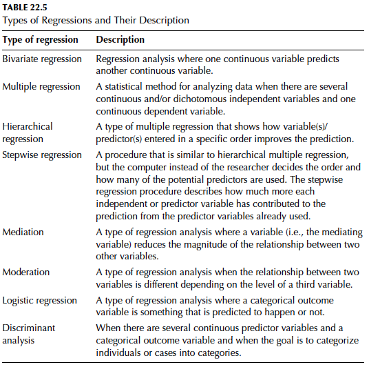